# PeerAssesment1

Tomasz Zajac

October 18, 2015

# My Peer Assesment 1

# Loading and preprocessing the data

## 1. Load the data

Read the activity data from the current working directory

```r
activity <- read.csv("activity.csv")
```

## 2. Process/transform the data (if necessary) into a format suitable for your analysis

No preprocessing required

# What is mean total number of steps taken per day?

For this part of the assignment, you can ignore the missing values in the dataset.

## 1. Calculate the total number of steps taken per day

```r
activitydaily <- aggregate(steps ~ date, activity, sum, na.action = NULL)
```

## 2. Make a histogram of daily number of steps

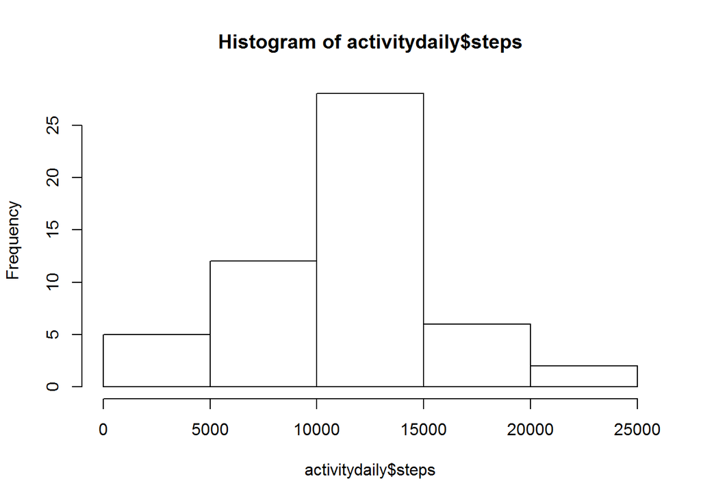

```r
hist(activitydaily$steps)
```

## 3. Calculate and report the mean and median of the total number of steps taken per day

Calculate and report the mean of the total number of steps taken per day

```r
mean(activitydaily$steps)
```

```
## [1] NA
```

Calculate and report the median of the total number of steps taken per day

```r
median(activitydaily$steps)
```

```
## [1] NA
```

# What is the average daily activity pattern?

## 1. Make a time series plot (i.e. type = “l”) of the 5-minute interval (x-axis) and the average number of steps taken, averaged across all days (y-axis)

Calculate interval means

```r
interval_means <- aggregate(steps ~ interval, activity, mean)
```

Plot inerval menas

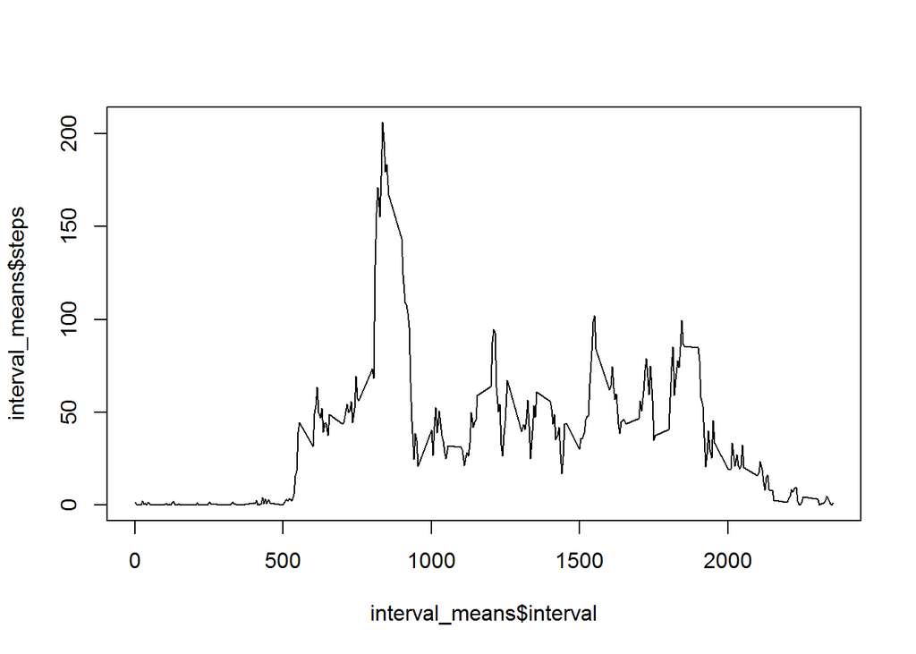

```r
plot(interval_means$interval, interval_means$steps, type = 'l')
```

## 2. Which 5-minute interval, on average across all the days in the dataset, contains the maximum number of steps?

```r
interval_means$interval[interval_means$steps == max(interval_means$steps)]
```

```
## [1] 835
```

# Imputing missing values

## 1. Calculate and report the total number of missing values in the dataset (i.e. the total number of rows with NAs)

```r
sum(is.na(activity$steps))
```

```
## [1] 2304
```

## 2. Devise a strategy for filling in all of the missing values in the dataset. The strategy does not need to be sophisticated. For example, you could use the mean/median for that day, or the mean for that 5-minute interval, etc.

Use mean for the 5 minute interval

## 3. Create a new dataset that is equal to the original dataset but with the missing data filled in.

Find row numbers with NA steps

```r
k <- which(is.na(activity$steps), arr.ind = TRUE)
```

Copy activity table

```r
activity2 <- activity
```

Overwrite NA’s with interval means

```r
activity2$steps[k] <- interval_means$steps[(k - 1) %% (60 / 5 * 24) + 1]
```

## 4.Make a histogram of the total number of steps taken each day and Calculate and report the mean and median total number of steps taken per day.

Calculate the total number of steps taken per day

```r
activity2daily <- aggregate(steps ~ date, activity2, sum)
```

Make a histogram of daily number of steps

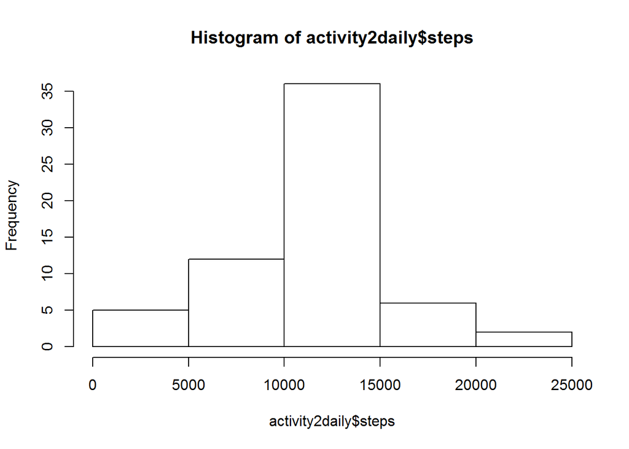

```r
hist(activity2daily$steps)
```

Calculate and report the mean of the total number of steps taken per day

```r
mean(activity2daily$steps)
```

```
## [1] 10766.19
```

Calculate and report the median of the total number of steps taken per day

```r
median(activity2daily$steps)
```

```
## [1] 10766.19
```

Q1: Do these values differ from the estimates from the first part of the assignment?

A1: Yes, mean is equal to median now.

Q2: What is the impact of imputing missing data on the estimates of the total daily number of steps?

A2: There is no impact for days where some acivity was recorded.

```r
activitydaily$steps - activity2daily$steps
```

```
##  [1] NA  0  0  0  0  0  0 NA  0  0  0  0  0  0  0  0  0  0  0  0  0  0  0
## [24]  0  0  0  0  0  0  0  0 NA  0  0 NA  0  0  0  0 NA NA  0  0  0 NA  0
## [47]  0  0  0  0  0  0  0  0  0  0  0  0  0  0 NA
```

# Are there differences in activity patterns between weekdays and weekends?

## 1. Create a new factor variable in the dataset with two levels - “weekday” and “weekend” indicating whether a given date is a weekday or weekend day.

Create a helper week_days table

```r
week_days <- as.data.frame(c("weekday", "weekday", "weekday", "weekday", "weekday", "weekend", "weekend"))
row.names(week_days) <- c("Monday", "Tuesday", "Wednesday", "Thursday", "Friday", "Saturday", "Sunday")
colnames(week_days) <- c("day")
week_days
```

```
##               day
## Monday    weekday
## Tuesday   weekday
## Wednesday weekday
## Thursday  weekday
## Friday    weekday
## Saturday  weekend
## Sunday    weekend
```

Add weekday/weekend column

```r
activity$weekday <- week_days[weekdays(as.Date(activity$date)),1]
```

Aggregate steps by weekday/weekend

```r
activityweekdaily <- aggregate(steps ~ interval + weekday, activity, mean)
```

## 2.Make a panel plot containing a time series plot (i.e. type = “l”) of the 5-minute interval (x-axis) and the average number of steps taken, averaged across all weekday days or weekend days (y-axis).

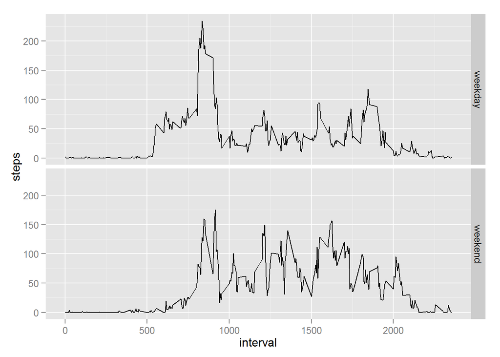

```r
library(ggplot2)
qplot(x = interval, y = steps, data = activityweekdaily, facets = weekday~., geom = "line")
```